# Video Game Sales Analysis

### by Yueh-Han Chen

### Dataset Overview

This dataset contains a list of video games with sales greater than 100,000 copies. It was generated by a scrape of vgchartz.com. (https://www.kaggle.com/gregorut/videogamesales)

### Research Question:

1. What genre had highest sales from 1980-2020?
2. What are top 5 Publishers by high global sales?
3. What are top 5 Platformss by high global sales?
4. Which 5 year of range from 1980 - 2020 has the highest global sales?
5. What is the relationship between sales numbers in 4 different main regions from 1980 - 2020?
6. What is the relationship between Top 5 Platforms and years ?
7. Among "Gerne", "Publisher", "year", and "Platform", which variable affected high global sales the most?

## Research Question 1: What genre had highest sales from 1980-2020?

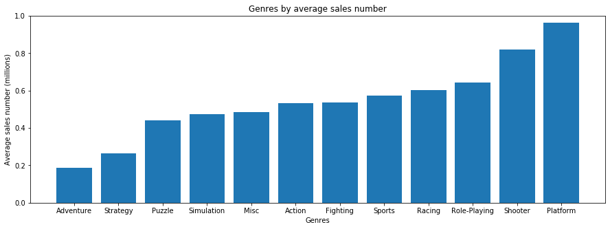

```python
# Visulization
plt.figure(figsize=(15,5))
plt.bar(range(0,12), list(clean_df.groupby('Genre')['Global_Sales'].mean().sort_values().values), tick_label=list(clean_df.groupby('Genre')['Global_Sales'].mean().sort_values().index))
plt.title('Genres by average sales number')
plt.xlabel('Genres')
plt.ylabel('Average sales number (millions)');
plt.ylim(0,1);
```

## Research Question 2: What are top 5 Publishers by high sales?

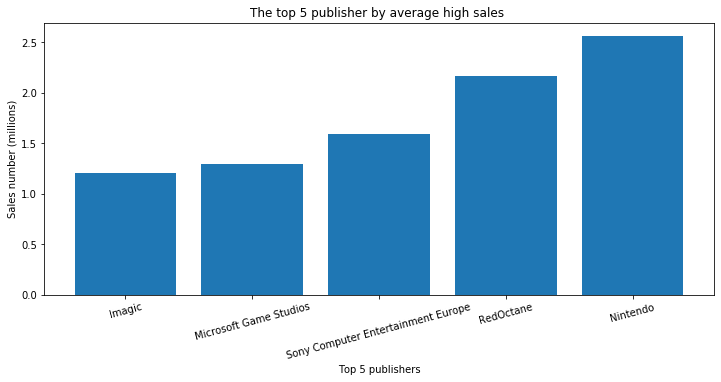

```python
#Visualization
plt.figure(figsize=(12,5))
plt.bar([1, 2, 3,4,5], [1.205, 1.30042328, 1.592 , 2.1725, 2.56354885], tick_label=['Imagic', 'Microsoft Game Studios',
       'Sony Computer Entertainment Europe', 'RedOctane', 'Nintendo'])
plt.title('The top 5 publisher by average high sales ')
plt.xlabel('Top 5 publishers')
plt.ylabel('Sales number (millions)');
plt.xticks(rotation=15);
```

## Research Question 3: What are top 5 Platforms by high sales?

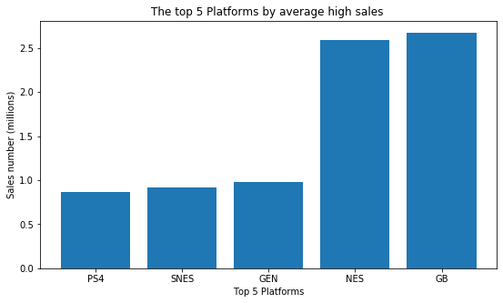

```python
#Visualization
plt.figure(figsize=(9,5))
plt.bar([1, 2, 3,4,5], [0.8608805, 0.92192488, 0.97875, 2.59473684, 2.67357895], tick_label=['PS4', 'SNES', 'GEN', 'NES', 'GB'])
plt.title('The top 5 Platforms by average high sales ')
plt.xlabel('Top 5 Platforms')
plt.ylabel('Sales number (millions)');
```

## Research Question 4: Which 5 year of range from 1980 - 2020 has the highest global sales?

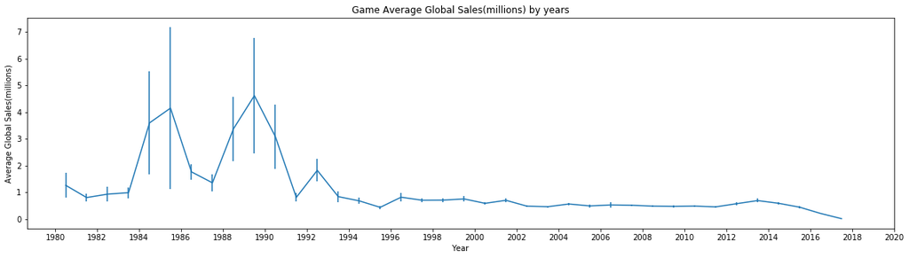

```python
# Visualization

plt.figure(figsize=(20,5))
# set bin edges, compute centers
bin_size = 1
xbin_edges = np.arange(1980, clean_df['Year'].max()+bin_size, bin_size)
xbin_centers = (xbin_edges + bin_size/2)[:-1]

# compute statistics in each bin
data_xbins = pd.cut(clean_df['Year'], xbin_edges, right = False, include_lowest = True)
y_means = clean_df['Global_Sales'].groupby(data_xbins).mean()
y_sems = clean_df['Global_Sales'].groupby(data_xbins).sem()  #std

# plot the summarized data
plt.errorbar(x = xbin_centers, y = y_means, yerr = y_sems)
plt.xlabel('Year')
plt.ylabel('Average Global Sales(millions)');
plt.xticks(range(1980,2021,2), range(1980,2021,2));
plt.title('Game Average Global Sales(millions) by years');
```

## Research Question 5: What is the relationship between sales numbers in 4 different main regions from 1980 - 2020?

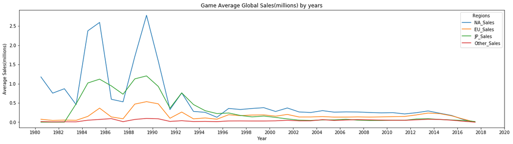

```python
# Visualization

plt.figure(figsize=(20,5))
# set bin edges, compute centers
bin_size = 1
xbin_edges = np.arange(1980, clean_df['Year'].max()+bin_size, bin_size)
xbin_centers = (xbin_edges + bin_size/2)[:-1]

# compute statistics in each bin
data_xbins = pd.cut(clean_df['Year'], xbin_edges, right = False, include_lowest = True)
y_means = clean_df['NA_Sales'].groupby(data_xbins).mean()
plt.errorbar(x = xbin_centers, y = y_means)
y_means = clean_df['EU_Sales'].groupby(data_xbins).mean()
plt.errorbar(x = xbin_centers, y = y_means)
y_means = clean_df['JP_Sales'].groupby(data_xbins).mean()
plt.errorbar(x = xbin_centers, y = y_means)
y_means = clean_df['Other_Sales'].groupby(data_xbins).mean()
plt.errorbar(x = xbin_centers, y = y_means)

# plot the summarized data
plt.xlabel('Year')
plt.ylabel('Average Sales(millions)');
plt.xticks(range(1980,2021,2), range(1980,2021,2));
plt.title('Game Average Global Sales(millions) by years');
plt.legend(title="Regions", labels=['NA_Sales','EU_Sales','JP_Sales','Other_Sales'])
```

## Research Question 6: What is the relationship between Top 5 Platforms and years ?

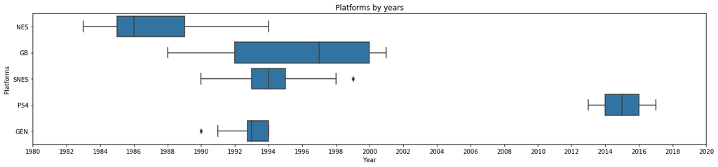

```python
# Visualization
#I only need the data from top platform
Top5platform_df = clean_df[clean_df['Platform'].isin(['PS4', 'SNES', 'GEN', 'NES', 'GB'])]
plt.figure(figsize=(20,4))
base_color = sb.color_palette()[0]
sb.boxplot(data = Top5platform_df, x = 'Year', y = 'Platform', color = base_color)
plt.xlabel('Year')
plt.ylabel('Platforms');
plt.xticks(range(1980,2021,2), range(1980,2021,2));
plt.title('Platforms by years');
```

## Research Question 7: Among "Top 5 Genres", "Top 5 Publisher", and "Top 5 Platform", which variable affected high global sales the most?

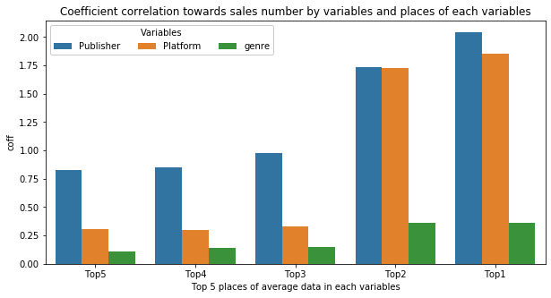

```python
# Visualize
plt.figure(figsize=(10,5))
ax = sb.barplot(data = coff_df, x = 'places', y = 'coff', hue = 'categories')
ax.legend(loc = 2, ncol = 3, framealpha = 1, title = 'Variables');
plt.title('Coefficient correlation towards sales number by variables and places of each variables')
plt.xlabel("Top 5 places of average data in each variables");
```